# HW4 SML

Jie Li jl5246

March 24, 2019

### Problem 1 Kernelized Nearest Neighbor Classification

#### 1

$$d^2(x, x') = ||x-x'||_2^2 = <(x-x'), (x-x')> = <x,x> - 2<x,x'> + <x',x'>$$

#### 2

$$d_k^2(x, x') = <\phi(x),\phi(x)> - 2<\phi(x),\phi(x')> + <\phi(x'),\phi(x')>$$

#### 3

d_k^2(x, x’) is itself a distance measure that map data $X$ into high-dimension feature space by `kernel` function and calculate the distances between data points $X$ in that space.

### Problem 2 Subset Selection Methods

First of all, take a look our `Credit` dataset

```r
data = read.csv("./Credit.csv")
head(data)
```

```
##   X  Income Limit Rating Cards Age Education Gender Student Married
## 1 1  14.891  3606    283     2  34        11   Male      No     Yes
## 2 2 106.025  6645    483     3  82        15 Female     Yes     Yes
## 3 3 104.593  7075    514     4  71        11   Male      No      No
## 4 4 148.924  9504    681     3  36        11 Female      No      No
## 5 5  55.882  4897    357     2  68        16   Male      No     Yes
## 6 6  80.180  8047    569     4  77        10   Male      No      No
##   Ethnicity Balance
## 1 Caucasian     333
## 2     Asian     903
## 3     Asian     580
## 4     Asian     964
## 5 Caucasian     331
## 6 Caucasian    1151
```

Using `Regsubsets` function to ientify the best model, which minimizes the residual sum-of-squares (RSS).

```r
model.set = regsubsets(Balance ~ Income + Limit + Rating + Cards + Age + Education + I(Gender) + I(Student) + I(Ethnicity) + I(Married), data)
summary(model.set)
```

```
## Subset selection object
## Call: regsubsets.formula(Balance ~ Income + Limit + Rating + Cards +
##     Age + Education + I(Gender) + I(Student) + I(Ethnicity) +
##     I(Married), data)
## 11 Variables  (and intercept)
##                       Forced in Forced out
## Income                    FALSE      FALSE
## Limit                     FALSE      FALSE
## Rating                    FALSE      FALSE
## Cards                     FALSE      FALSE
## Age                       FALSE      FALSE
## Education                 FALSE      FALSE
## I(Gender)Female           FALSE      FALSE
## I(Student)Yes             FALSE      FALSE
## I(Ethnicity)Asian         FALSE      FALSE
## I(Ethnicity)Caucasian     FALSE      FALSE
## I(Married)Yes             FALSE      FALSE
## 1 subsets of each size up to 8
## Selection Algorithm: exhaustive
##          Income Limit Rating Cards Age Education I(Gender)Female
## 1  ( 1 ) " "    " "   "*"    " "   " " " "       " "
## 2  ( 1 ) "*"    " "   "*"    " "   " " " "       " "
## 3  ( 1 ) "*"    " "   "*"    " "   " " " "       " "
## 4  ( 1 ) "*"    "*"   " "    "*"   " " " "       " "
## 5  ( 1 ) "*"    "*"   "*"    "*"   " " " "       " "
## 6  ( 1 ) "*"    "*"   "*"    "*"   "*" " "       " "
## 7  ( 1 ) "*"    "*"   "*"    "*"   "*" " "       "*"
## 8  ( 1 ) "*"    "*"   "*"    "*"   "*" " "       "*"
##          I(Student)Yes I(Ethnicity)Asian I(Ethnicity)Caucasian
## 1  ( 1 ) " "           " "               " "
## 2  ( 1 ) " "           " "               " "
## 3  ( 1 ) "*"           " "               " "
## 4  ( 1 ) "*"           " "               " "
## 5  ( 1 ) "*"           " "               " "
## 6  ( 1 ) "*"           " "               " "
## 7  ( 1 ) "*"           " "               " "
## 8  ( 1 ) "*"           "*"               " "
##          I(Married)Yes
## 1  ( 1 ) " "
## 2  ( 1 ) " "
## 3  ( 1 ) " "
## 4  ( 1 ) " "
## 5  ( 1 ) " "
## 6  ( 1 ) " "
## 7  ( 1 ) " "
## 8  ( 1 ) " "
```

Performing `forward stepwise selection`

```r
model.foward = regsubsets(Balance ~ Income + Limit + Rating + Cards + Age + Education + I(Gender) + I(Student) + I(Ethnicity) + I(Married), data, method = "forward")
summary(model.foward)
```

```
## Subset selection object
## Call: regsubsets.formula(Balance ~ Income + Limit + Rating + Cards +
##     Age + Education + I(Gender) + I(Student) + I(Ethnicity) +
##     I(Married), data, method = "forward")
## 11 Variables  (and intercept)
##                       Forced in Forced out
## Income                    FALSE      FALSE
## Limit                     FALSE      FALSE
## Rating                    FALSE      FALSE
## Cards                     FALSE      FALSE
## Age                       FALSE      FALSE
## Education                 FALSE      FALSE
## I(Gender)Female           FALSE      FALSE
## I(Student)Yes             FALSE      FALSE
## I(Ethnicity)Asian         FALSE      FALSE
## I(Ethnicity)Caucasian     FALSE      FALSE
## I(Married)Yes             FALSE      FALSE
## 1 subsets of each size up to 8
## Selection Algorithm: forward
##          Income Limit Rating Cards Age Education I(Gender)Female
## 1  ( 1 ) " "    " "   "*"    " "   " " " "       " "
## 2  ( 1 ) "*"    " "   "*"    " "   " " " "       " "
## 3  ( 1 ) "*"    " "   "*"    " "   " " " "       " "
## 4  ( 1 ) "*"    "*"   "*"    " "   " " " "       " "
## 5  ( 1 ) "*"    "*"   "*"    "*"   " " " "       " "
## 6  ( 1 ) "*"    "*"   "*"    "*"   "*" " "       " "
## 7  ( 1 ) "*"    "*"   "*"    "*"   "*" " "       "*"
## 8  ( 1 ) "*"    "*"   "*"    "*"   "*" " "       "*"
##          I(Student)Yes I(Ethnicity)Asian I(Ethnicity)Caucasian
## 1  ( 1 ) " "           " "               " "
## 2  ( 1 ) " "           " "               " "
## 3  ( 1 ) "*"           " "               " "
## 4  ( 1 ) "*"           " "               " "
## 5  ( 1 ) "*"           " "               " "
## 6  ( 1 ) "*"           " "               " "
## 7  ( 1 ) "*"           " "               " "
## 8  ( 1 ) "*"           "*"               " "
##          I(Married)Yes
## 1  ( 1 ) " "
## 2  ( 1 ) " "
## 3  ( 1 ) " "
## 4  ( 1 ) " "
## 5  ( 1 ) " "
## 6  ( 1 ) " "
## 7  ( 1 ) " "
## 8  ( 1 ) " "
```

Performing `backward stepwise selection`

```r
model.backward = regsubsets(Balance ~ Income + Limit + Rating + Cards + Age + Education + I(Gender) + I(Student) + I(Ethnicity) + I(Married), data, method = "backward")
summary(model.backward)
```

```
## Subset selection object
## Call: regsubsets.formula(Balance ~ Income + Limit + Rating + Cards +
##     Age + Education + I(Gender) + I(Student) + I(Ethnicity) +
##     I(Married), data, method = "backward")
## 11 Variables  (and intercept)
##                       Forced in Forced out
## Income                    FALSE      FALSE
## Limit                     FALSE      FALSE
## Rating                    FALSE      FALSE
## Cards                     FALSE      FALSE
## Age                       FALSE      FALSE
## Education                 FALSE      FALSE
## I(Gender)Female           FALSE      FALSE
## I(Student)Yes             FALSE      FALSE
## I(Ethnicity)Asian         FALSE      FALSE
## I(Ethnicity)Caucasian     FALSE      FALSE
## I(Married)Yes             FALSE      FALSE
## 1 subsets of each size up to 8
## Selection Algorithm: backward
##          Income Limit Rating Cards Age Education I(Gender)Female
## 1  ( 1 ) " "    "*"   " "    " "   " " " "       " "
## 2  ( 1 ) "*"    "*"   " "    " "   " " " "       " "
## 3  ( 1 ) "*"    "*"   " "    " "   " " " "       " "
## 4  ( 1 ) "*"    "*"   " "    "*"   " " " "       " "
## 5  ( 1 ) "*"    "*"   "*"    "*"   " " " "       " "
## 6  ( 1 ) "*"    "*"   "*"    "*"   "*" " "       " "
## 7  ( 1 ) "*"    "*"   "*"    "*"   "*" " "       "*"
## 8  ( 1 ) "*"    "*"   "*"    "*"   "*" " "       "*"
##          I(Student)Yes I(Ethnicity)Asian I(Ethnicity)Caucasian
## 1  ( 1 ) " "           " "               " "
## 2  ( 1 ) " "           " "               " "
## 3  ( 1 ) "*"           " "               " "
## 4  ( 1 ) "*"           " "               " "
## 5  ( 1 ) "*"           " "               " "
## 6  ( 1 ) "*"           " "               " "
## 7  ( 1 ) "*"           " "               " "
## 8  ( 1 ) "*"           "*"               " "
##          I(Married)Yes
## 1  ( 1 ) " "
## 2  ( 1 ) " "
## 3  ( 1 ) " "
## 4  ( 1 ) " "
## 5  ( 1 ) " "
## 6  ( 1 ) " "
## 7  ( 1 ) " "
## 8  ( 1 ) " "
```

#### 1

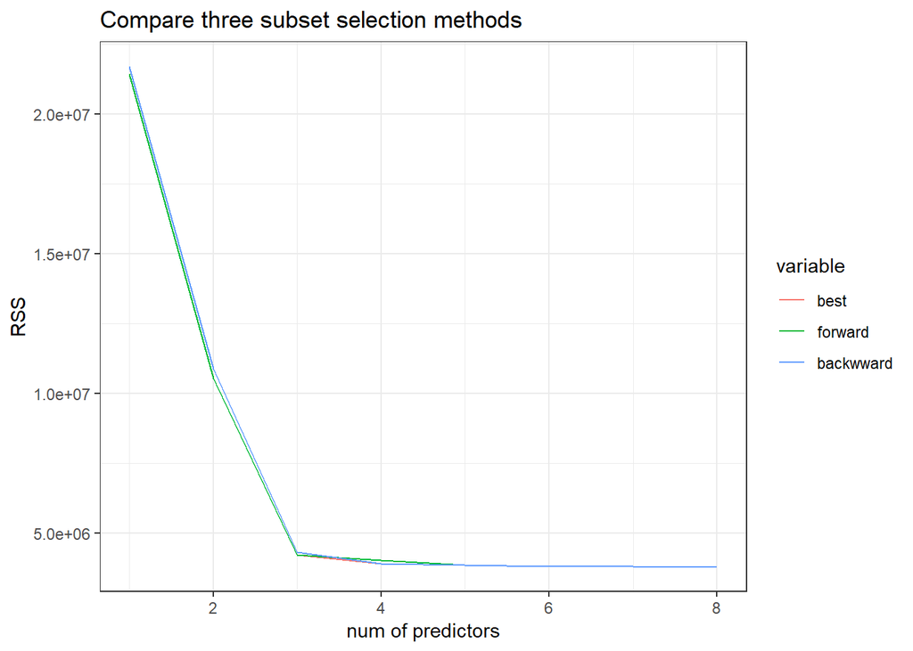

```r
RSS.df = data.frame(n = 1:8, best = summary(model.set)$rss, forward = summary(model.foward)$rss, backwward = summary(model.backward)$rss)

RSS.df %>% melt(id.var = "n") %>%
ggplot()+
  geom_line(aes(n, value, col = variable))+
  xlab("num of predictors")+
  ylab("RSS")+
  ggtitle("Compare three subset selection methods")+
  theme_bw()
```

#### 2

Each subset selection method results in a set of models. For each approach, choose a single optimal model by using Cp and BIC statistics respectively.

```r
cat("The lowest Cp and BIC in the Best subset selection: ", min(summary(model.set)$cp), min(summary(model.set)$bic), "\n")
```

```
## The lowest Cp and BIC in the Best subset selection:  5.574883 -1198.053
```

```r
cat("The lowest Cp and BIC in the foward subset selection: ", min(summary(model.foward)$cp), min(summary(model.foward)$bic), "\n")
```

```
## The lowest Cp and BIC in the foward subset selection:  5.574883 -1197.096
```

```r
cat("The lowest Cp and BIC in the backward subset selection: ", min(summary(model.backward)$cp), min(summary(model.backward)$bic), "\n")
```

```
## The lowest Cp and BIC in the backward subset selection:  5.574883 -1198.053
```

I am going to choose `BIC` statistcs from the `Best subset selection` because it provides the lowest and simplest model.

```r
cat("Following is the given number of predictors \n")
```

```
## Following is the given number of predictors
```

```r
summary(model.set)$outmat[which.min(summary(model.set)$bic),]
```

```
##                Income                 Limit                Rating
##                   "*"                   "*"                   " "
##                 Cards                   Age             Education
##                   "*"                   " "                   " "
##       I(Gender)Female         I(Student)Yes     I(Ethnicity)Asian
##                   " "                   "*"                   " "
## I(Ethnicity)Caucasian         I(Married)Yes
##                   " "                   " "
```

### Problem 3 SVM

Loading the data set

```r
### all images corresponding to digit "5"
zip.5 = read.table("train.5-1.txt", header = FALSE, sep = ",")
zip.5 = cbind(zip.5, y=rep(-1, dim(zip.5)[1])) %>% data.frame()

### all images corresponding to digit "6"
zip.6 = read.table("train.6.txt", header = FALSE, sep = ",")
zip.6 = cbind(zip.6, y=rep(1, dim(zip.6)[1])) %>% data.frame()

### combine two data sets together
data = rbind(zip.5, zip.6)

# function of visualizing the image
output.image = function(data)
{
  # Transfer dataframe to vector then convert to matrix
    digit = matrix(as.numeric(data), nrow = 16, ncol = 16)

    # Set index backwards
    index = seq(from = 16, to  = 1, by = -1)
    sym_digit = digit[,index]
    image(sym_digit, col = gray((8:0)/8), axes = FALSE)
}
```

Visualizing the part of dataset

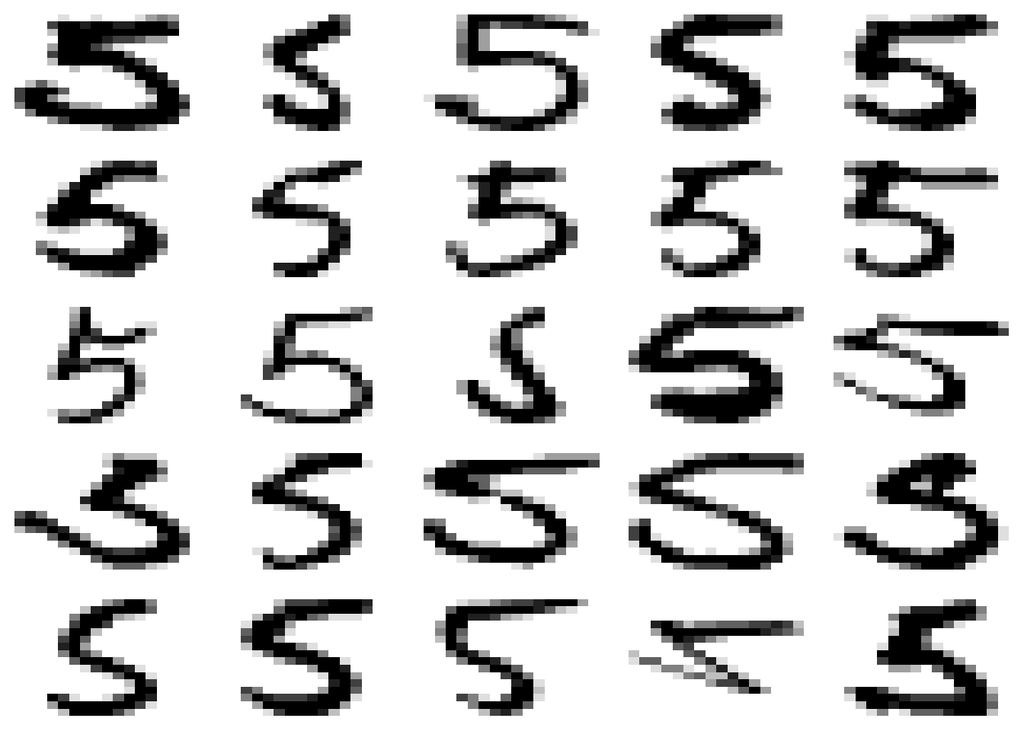

```r
# Visualize digital 5
par(mfrow = c(5,5),mai = c(0.1,0.1,0.1,0.1))
for(i in 1:25)
{
    output.image(zip.5[i,-257])
}
```

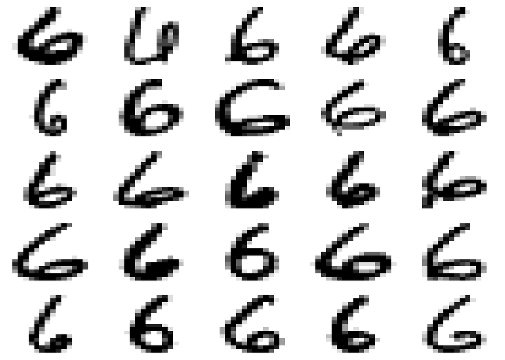

```r
# Visualize digital 6
par(mfrow = c(5,5),mai = c(0.1,0.1,0.1,0.1))
for(i in 1:25)
{
    output.image(zip.6[i,-257])
}
```

Spliting train and test set, repectively 80-20

```r
set.seed(123)
index = sample(1:dim(data)[1], dim(data)[1]*0.2)
test = data[index,]
train = data[-index,]

cat("Dimension of Training set: ", dim(train), "\n")
```

```
## Dimension of Training set:  976 257
```

```r
cat("Dimension of Test set: ", dim(test))
```

```
## Dimension of Test set:  244 257
```

Training linear SVM, and tuning hyperparameters by 10-fold cross validation

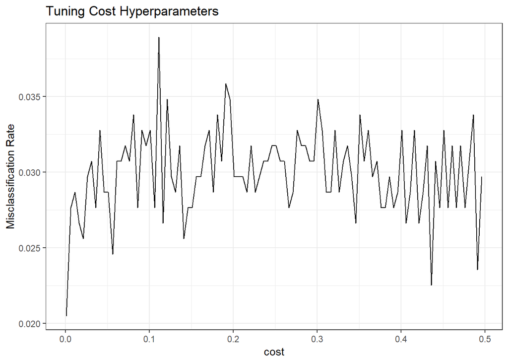

```r
cost = seq(0.001,0.5, 0.005)
mis.rate = c()

for(i in cost)
{
  model1 = svm(y ~., train, type = "C-classification", kernel = "linear", cost = i, cross = 10)
  mis.rate = c(mis.rate, 1-summary(model1)$"tot.accuracy"/100)
}

ggplot()+
  geom_line(aes(cost, mis.rate), size = 0.5)+
  ylab("Misclassification Rate")+
  ggtitle("Tuning Cost Hyperparameters")+
  theme_bw()
```

```r
cat("The best hyperparameter of cost is:", cost[which.min(mis.rate)])
```

```
## The best hyperparameter of cost is: 0.001
```

Using the optimal parameters to refit SVM, and calcating misclassification rate

```r
model1.tune = svm(y ~., train, type = "C-classification", kernel = "linear", cost = 0.001)
summary(model1.tune)
```

```
##
## Call:
## svm(formula = y ~ ., data = train, type = "C-classification",
##     kernel = "linear", cost = 0.001)
##
##
## Parameters:
##    SVM-Type:  C-classification
##  SVM-Kernel:  linear
##        cost:  0.001
##       gamma:  0.00390625
##
## Number of Support Vectors:  227
##
##  ( 112 115 )
##
##
## Number of Classes:  2
##
## Levels:
##  -1 1
```

```r
y.pred = predict(model1.tune, test)
cat("The misclassification rate on the test set:", mean(test$y != y.pred))
```

```
## The misclassification rate on the test set: 0.01639344
```

Training `RBF` kernel SVM, and tuning hyperparameters by 10-fold cross validation

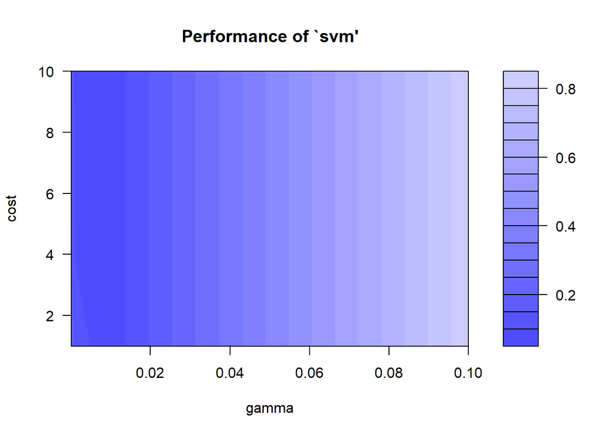

```r
cost = seq(1,10,1)
gamma = c(10^(-1:-4))

svm_tune = tune.svm(y ~., data = train, kernel="radial", scale=F, cost = cost, gamma = gamma)

plot(svm_tune)
```

```r
summary(svm_tune)
```

```
##
## Parameter tuning of 'svm':
##
## - sampling method: 10-fold cross validation
##
## - best parameters:
##  gamma cost
##   0.01    2
##
## - best performance: 0.06648839
##
## - Detailed performance results:
##    gamma cost      error dispersion
## 1  1e-01    1 0.83758137 0.03407352
## 2  1e-02    1 0.06816863 0.02363817
```

[output cut: 38 more lines]

```r
cat("The best hyperparameter of cost =", svm_tune$best.parameters[1,1], "Gamma = ", svm_tune$best.parameters[1,2])
```

```
## The best hyperparameter of cost = 0.01 Gamma =  2
```

Using the optimal parameters to refit SVM, and calcating misclassification rate

```r
model.tune = svm(y ~., train, type = "C-classification", kernel = "radial", cost = 2, gamma = 0.01)
summary(model.tune)
```

```
##
## Call:
## svm(formula = y ~ ., data = train, type = "C-classification",
##     kernel = "radial", cost = 2, gamma = 0.01)
##
##
## Parameters:
##    SVM-Type:  C-classification
##  SVM-Kernel:  radial
##        cost:  2
##       gamma:  0.01
##
## Number of Support Vectors:  514
##
##  ( 299 215 )
##
##
## Number of Classes:  2
##
## Levels:
##  -1 1
```

```r
y.pred = predict(model.tune, test)
cat("The misclassification rate on the test set: ", mean(test$y != y.pred))
```

```
## The misclassification rate on the test set:  0.01229508
```

For conclusion, the `RBF` kernel SVM has better performance on the test set, which misclassification rate is 0.0123. And the hpyerparameter I selected is $Cost = 2, Gamma = 0.01$